# Pseudo-bulk replicates & Peak calling

# Load Libraries & ArchR object

```r
library(ArchR)
library(rhdf5)
library(reticulate)
library(tidyverse)

h5disableFileLocking()

# load ArchR project
proj2 <- loadArchRProject(path = "Vignette_object_1/")

# for R to find macs2 we will use a conda environment where the latest version
# of macs2 is installed
conda_list()[[1]][2] %>% use_condaenv(required = TRUE)
```

# Pseudo-bulk replicates

For statistical signficance we need replicates, which is not given in the binary single cell data obtained from scATAC-seq. Therefore, we create pseudo-bulk replicates. We group single cells and the data of all the cells in the group are combined into a pseudo-sample that resembles a bulk-ATAC-seq experiment. For each cell grouping several pseudo-bulks are created, resulting in pseudo-bulk replicates. The main assumption here is that the cells we group together are so similar that we are not interested in the differences between them. We group cells together based on clusters and known cell identities.

Parameters:

- minReps, maxReps: min. and max. number of replicates
- minCells, maxCells: min. and max. number of cells per replicate
- SamplingRatio: sampling ratio to use if a particular group of cells does not have required number e.g. 0.8 means that 80% of cells can be sampled without replacement for a particular replicate

Using the generated pseudo-bulk replicates, peak calling can be done.

The `groupBy` parameter specifies for which groups pseudo-bulk replicates should be made. With pseudo-bulks you can call peaks next, because we do not want to call peaks on all single cells together.

```r
proj2 <- addGroupCoverages(ArchRProj = proj2, groupBy = "Clusters2")
```

# Peak calling

https://hbctraining.github.io/Intro-to-ChIPseq/lessons/05_peak_calling_macs.html

Because the scATAC-seq data is binary, peaks cannot be called on single cells. Using pseuod-bulk replicates we can assess the reproducibility of our peak calls.

ArchR uses a fixed peak width as opposed to a variable peak width, because then peak length does not need to be normalized and it is easier to merge peaks from different saples. The peak length used is 501bp, since most peaks are smaller than 501 bp.

## Iterative Overlap

1. rank peaks by their signficance
2. the most significant peak is retained
3. any peak overlapping with the most significant peak is removed
4. the process is repeated for the remaining peaks

For example, if we hae 3 ell types A, B, C and 3 pseudo-bulk replicates for each:

1. Call peaks for each pseudo-bulk replicate individually
2. The first iteration of iterative overlap would then be performed on all pseuo- bulk replicates from a single cell type. (It is important to normalize peak significance across different samples beforehand)
3. Check the reproducibility of each peak across pseud9-bulk replicates and only keep the peaks that pass a threshold
4. You now have a single merged peak set for each of the 3 cell types
5. proceed with iterative overlap remove to merge A, B, C peak sets (It is important to re-normalize the peak significance across different cell types at this step)

**At the end you are left with a single merged peak set of fixed-width peaks.**

Cell are then defined as accessible at a particular peak if a read from that cell overlapped the peak.

```r
proj2 <- addReproduciblePeakSet(
    ArchRProj = proj2,
    groupBy = "Clusters2",
    pathToMacs2 = "/home/k552k/.conda/envs/scDori/bin/macs2"
)
##                 Group nCells nCellsUsed nReplicates nMin nMax maxPeaks
## B                   B    482        475           2  170  305   150000
## CD4.M           CD4.M    524        523           2   51  472   150000
## CD4.N           CD4.N   1352        612           2  112  500   150000
## CLP               CLP    310        310           2   40  270   150000
## Erythroid   Erythroid    823        692           2  192  500   150000
## GMP               GMP   1066        854           2  354  500   150000
## Mono             Mono   2561       1000           2  500  500   150000
## NK                 NK    907        823           2  323  500   150000
## pDC               pDC    272        264           2  118  146   132000
## PreB             PreB    386        386           2   40  346   150000
## Progenitor Progenitor   1567        660           2  160  500   150000
## [1] "/omics/groups/OE0533/internal/katharina/scDoRI/ArchR/Vignette_object_1/PeakCalls/B-reproduciblePeaks.gr.rds"
## [1] "/omics/groups/OE0533/internal/katharina/scDoRI/ArchR/Vignette_object_1/PeakCalls/CD4.M-reproduciblePeaks.gr.rds"
## [1] "/omics/groups/OE0533/internal/katharina/scDoRI/ArchR/Vignette_object_1/PeakCalls/CD4.N-reproduciblePeaks.gr.rds"
## [1] "/omics/groups/OE0533/internal/katharina/scDoRI/ArchR/Vignette_object_1/PeakCalls/CLP-reproduciblePeaks.gr.rds"
## [1] "/omics/groups/OE0533/internal/katharina/scDoRI/ArchR/Vignette_object_1/PeakCalls/Erythroid-reproduciblePeaks.gr.rds"
## [1] "/omics/groups/OE0533/internal/katharina/scDoRI/ArchR/Vignette_object_1/PeakCalls/GMP-reproduciblePeaks.gr.rds"
## [1] "/omics/groups/OE0533/internal/katharina/scDoRI/ArchR/Vignette_object_1/PeakCalls/Mono-reproduciblePeaks.gr.rds"
## [1] "/omics/groups/OE0533/internal/katharina/scDoRI/ArchR/Vignette_object_1/PeakCalls/NK-reproduciblePeaks.gr.rds"
## [1] "/omics/groups/OE0533/internal/katharina/scDoRI/ArchR/Vignette_object_1/PeakCalls/pDC-reproduciblePeaks.gr.rds"
## [1] "/omics/groups/OE0533/internal/katharina/scDoRI/ArchR/Vignette_object_1/PeakCalls/PreB-reproduciblePeaks.gr.rds"
## [1] "/omics/groups/OE0533/internal/katharina/scDoRI/ArchR/Vignette_object_1/PeakCalls/Progenitor-reproduciblePeaks.gr.rds"
```

We can retrieve this peak set as a `GRanges` object. Which will contain an annotation for the group from which each peak originated. This does not mean that the given peak was only called in that group, but rather that the annotated group had the highest normalized significanc for that peak call.

A **GRanges** object is a vector of genomic locations and associated annotations.

- sequence name
- interval
- strand
- optional metadata column

```r
getPeakSet(proj2)
## GRanges object with 141025 ranges and 13 metadata columns:
##             seqnames              ranges strand |     score
##                <Rle>           <IRanges>  <Rle> | <numeric>
##        Mono     chr1       752506-753006      * |  29.38902
##           B     chr1       762688-763188      * |  50.07557
##         GMP     chr1       773653-774153      * |   7.92061
##           B     chr1       801007-801507      * |  15.14324
##           B     chr1       805041-805541      * |  39.74110
##         ...      ...                 ...    ... .       ...
##        Mono     chrX 154840753-154841253      * |   2.16792
##          NK     chrX 154842390-154842890      * |  15.77700
##          NK     chrX 154862033-154862533      * |  12.34180
##   Erythroid     chrX 154912392-154912892      * |   6.11500
##         GMP     chrX 154997007-154997507      * |   4.91752
##             replicateScoreQuantile groupScoreQuantile Reproducibility
##                          <numeric>          <numeric>       <numeric>
##        Mono                  0.875              0.759               2
##           B                  0.939              0.858               2
##         GMP                  0.644              0.320               2
##           B                  0.693              0.443               2
##           B                  0.940              0.866               2
##         ...                    ...                ...             ...
##        Mono                  0.215              0.040               2
##          NK                  0.731              0.539               2
##          NK                  0.497              0.205               2
##   Erythroid                  0.301              0.078               2
##         GMP                  0.508              0.178               2
##                     GroupReplicate distToGeneStart nearestGene    peakType
##                        <character>       <integer> <character> <character>
##        Mono  Mono._.scATAC_BMMC_R1           10145   LINC00115      Distal
##           B     B._.scATAC_PBMC_R1              32   LINC01128    Promoter
##         GMP GMP._.scATAC_CD34_BM..           10931   LINC01128    Intronic
##           B     B._.scATAC_PBMC_R1           10924      FAM41C      Distal
##           B     B._.scATAC_BMMC_R1            6890      FAM41C    Intronic
##         ...                    ...             ...         ...         ...
##        Mono  Mono._.scATAC_BMMC_R1            1618       TMLHE    Intronic
##          NK    NK._.scATAC_BMMC_R1              17       TMLHE    Promoter
##          NK    NK._.scATAC_PBMC_R1           19660       TMLHE      Distal
##   Erythroid Erythroid._.scATAC_C..           70019       TMLHE      Distal
##         GMP GMP._.scATAC_CD34_BM..          154634       TMLHE      Distal
##             distToTSS  nearestTSS        GC       idx         N
##             <integer> <character> <numeric> <integer> <numeric>
##        Mono     10145  uc010nxx.2    0.4830         1         0
##           B        32  uc031pjj.1    0.6966         2         0
##         GMP     10724  uc031pjk.1    0.4611         3         0
##           B     10924  uc001abt.4    0.4371         4         0
##           B      6890  uc001abt.4    0.7305         5         0
##         ...       ...         ...       ...       ...       ...
##        Mono      1618  uc004fnn.3    0.4750      3425         0
##          NK        17  uc004fnn.3    0.6008      3426         0
##          NK     19660  uc004fnn.3    0.4251      3427         0
##   Erythroid     70019  uc004fnn.3    0.3573      3428         0
##         GMP       193  uc004fnq.1    0.5389      3429         0
##   -------
##   seqinfo: 23 sequences from an unspecified genome; no seqlengths
```

```
saveArchRProject(ArchRProj = proj2, outputDirectory = "Save_Vignette_object_2", load = FALSE)
```

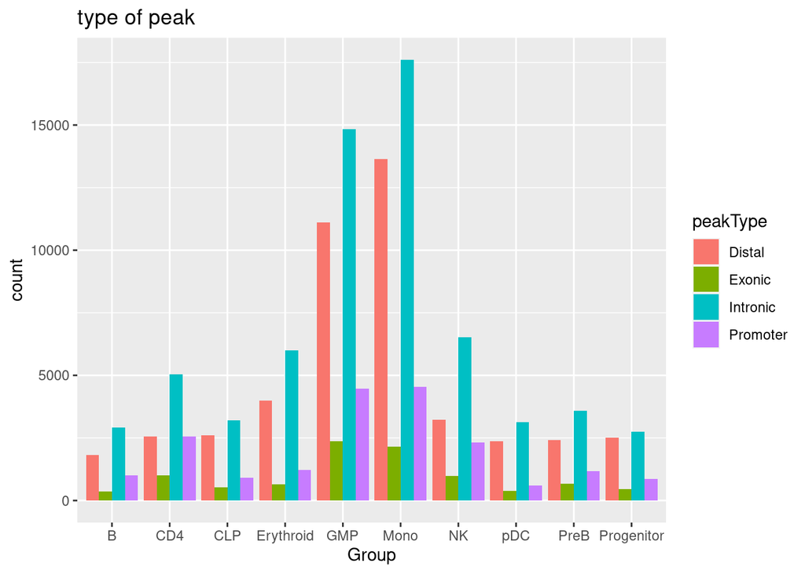

```r
peakset <- as_data_frame(getPeakSet(proj2))
## Warning: `as_data_frame()` was deprecated in tibble 2.0.0.
## Please use `as_tibble()` instead.
## The signature and semantics have changed, see `?as_tibble`.

p1 <- peakset %>%
  mutate(Group = str_extract(peakset[["GroupReplicate"]], "(?<!.)[^.]+")) %>%
  ggplot() +
  geom_bar(aes(x = Group, fill = peakType), position = "dodge") +
  labs(title = "type of peak")
p1
```

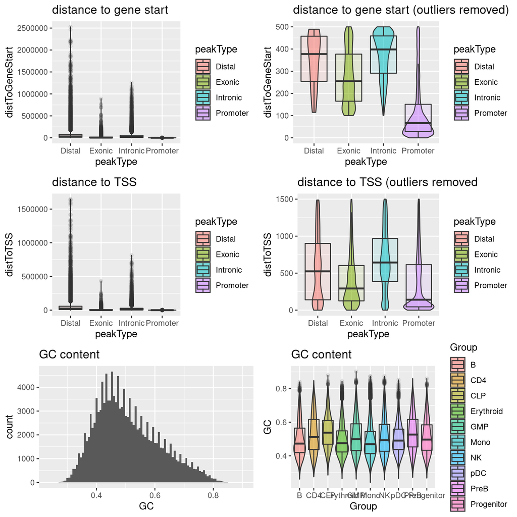

```r
p2 <- peakset %>%
  ggplot() +
  geom_violin(aes(x = peakType, y = distToGeneStart, fill = peakType),
              alpha = .5) +
  geom_boxplot(aes(x = peakType, y = distToGeneStart, fill = peakType),
               alpha = .1) +
  labs(title = "distance to gene start")

p3 <- peakset %>%
  ggplot() +
  geom_violin(aes(x = peakType, y = distToGeneStart, fill = peakType), outlier.shape = NA,
              alpha = .5) +
  geom_boxplot(aes(x = peakType, y = distToGeneStart, fill = peakType), outlier.shape = NA,
               alpha = .1) +
  ylim(0, 500) +
  labs(title = "distance to gene start (outliers removed)")
## Warning: Ignoring unknown parameters: outlier.shape

p4 <- peakset %>%
  ggplot() +
  geom_violin(aes(x = peakType, y = distToTSS, fill = peakType),
                  alpha = .5) +
  geom_boxplot(aes(x = peakType, y = distToTSS, fill = peakType), alpha = .1) +
  labs(title = "distance to TSS")

p5 <- peakset %>%
  ggplot() +
  geom_violin(aes(x = peakType, y = distToTSS, fill = peakType),
                  alpha = .5, outlier.shape = NA ) +
  geom_boxplot(aes(x = peakType, y = distToTSS, fill = peakType),
               alpha = .1, outlier.shape = NA) +
  ylim(0, 1500) +
  labs(title = "distance to TSS (outliers removed")
## Warning: Ignoring unknown parameters: outlier.shape

p6 <- peakset %>%
  mutate(Group = str_extract(peakset[["GroupReplicate"]], "(?<!.)[^.]+")) %>%
  ggplot() +
  geom_histogram(aes(x = GC), bins = 100) +
  labs(title = "GC content")

p7 <- peakset %>%
  mutate(Group = str_extract(peakset[["GroupReplicate"]], "(?<!.)[^.]+")) %>%
  ggplot() +
  geom_violin(aes(x = Group, y = GC, fill = Group), alpha = .5) +
  geom_boxplot(aes(x = Group, y = GC, fill = Group), alpha = .1) +
  labs(title = "GC content")


gridExtra::grid.arrange(p2, p3, p4, p5, p6, p7, ncol = 2)
## Warning: Removed 125423 rows containing non-finite values (stat_ydensity).
## Warning: Removed 125423 rows containing non-finite values (stat_boxplot).
## Warning: Removed 103440 rows containing non-finite values (stat_ydensity).
## Warning: Removed 103440 rows containing non-finite values (stat_boxplot).
```

```r
proj3 <- addPeakMatrix(proj2)
```

# Marker Peaks

```r
table(proj3$Clusters2)
##
##          B      CD4.M      CD4.N        CLP  Erythroid        GMP       Mono
##        482        524       1352        310        823       1066       2561
##         NK        pDC       PreB Progenitor
##        907        272        386       1567
```

We want to account for differences in data quality amongst the cell groups by setting the `bias` parameter to account for TSS enrichment and the number of unique fragments per cell. The function uses a pairwise wilcoxon test to compare different groups among each other. The output will be a Summarized Experiment containing a few assays.

```r
markersPeaks <- getMarkerFeatures(
    ArchRProj = proj3,
    useMatrix = "PeakMatrix",
    groupBy = "Clusters2",
    bias = c("TSSEnrichment", "log10(nFrags)"),
    testMethod = "wilcoxon"
)
```

For each peak we get 7 different assays, namely log2FC, mean, FDR, Pval MeanDiff, AUC and MeanBGD. Lets have a closer look at these results.

We have 141.025 called peaks and their corresponding seqnames, index and start and end.

```r
markersPeaks
## class: SummarizedExperiment
## dim: 141025 11
## metadata(2): MatchInfo Params
## assays(7): Log2FC Mean ... AUC MeanBGD
## rownames(141025): 1 2 ... 141024 141025
## rowData names(4): seqnames idx start end
## colnames(11): B CD4.M ... PreB Progenitor
## colData names(0):

assays(markersPeaks)[[1]] %>% head %>%
  knitr::kable(caption = "log2FC")
```

log2FC

| B | CD4.M | CD4.N | CLP | Erythroid | GMP | Mono | NK | pDC | PreB | Progenitor |
| --- | --- | --- | --- | --- | --- | --- | --- | --- | --- | --- |
| -2.4550599 | -1.9786690 | -3.5473930 | -1.0711421 | -1.2116873 | -0.8194933 | 2.4131641 | 0.1647097 | -1.9435270 | -3.4977521 | 0.3093068 |
| -0.4947969 | 0.2983331 | -0.3094854 | -0.0712008 | -0.7075576 | -0.7834563 | -0.2944861 | 0.7910184 | -1.5321925 | -0.8853021 | -0.1418114 |
| -3.9089018 | -2.3194546 | 0.0000000 | 0.0000000 | 1.7897013 | 1.5466049 | -1.8712502 | -2.3721394 | 3.2636790 | 2.2499442 | 1.4280161 |
| 5.2875183 | -3.1422556 | 0.0000000 | 1.1517730 | -2.1471096 | -2.9593822 | -3.9959388 | -3.1949909 | 0.0000000 | 4.1463564 | -0.9440683 |
| 1.5678540 | -0.2874332 | -0.1894716 | 0.2352725 | -0.1586969 | 0.0510056 | -0.9435466 | -0.4615618 | 0.1569869 | -0.2268936 | -0.6963519 |
| -4.9479301 | -3.8862839 | -1.8868311 | 4.1101334 | -0.1409942 | -1.3773290 | -1.6912565 | -4.3842145 | -0.0295769 | 4.5370097 | 5.4787436 |

```r
assays(markersPeaks)[[3]] %>% head %>%
  knitr::kable(caption = "False Discovery Rate")
```

False Discovery Rate

| B | CD4.M | CD4.N | CLP | Erythroid | GMP | Mono | NK | pDC | PreB | Progenitor |
| --- | --- | --- | --- | --- | --- | --- | --- | --- | --- | --- |
| 0.5058031 | 0.1544914 | 0.3482868 | 0.7979601 | 0.8332369 | 0.6752216 | 0.0529613 | 1.0000000 | 0.5170456 | 0.4686560 | 1.0000000 |
| 0.5583369 | 0.3269195 | 0.4548756 | 0.7209566 | 0.3415734 | 0.4148242 | 0.7269759 | 0.0787493 | 0.5207655 | 0.4498179 | 0.7908460 |
| 0.4515466 | 0.4409463 | NA | NA | 0.5082598 | 0.7103922 | 0.4856361 | 0.4374176 | 0.5207655 | 0.4939237 | 0.4305537 |
| 0.0967947 | 0.1696678 | NA | 0.4953460 | 0.5082598 | 0.6135785 | 0.2646956 | 0.1532564 | NA | 0.4939237 | 0.7422701 |
| 0.4627745 | 0.6306507 | 1.0000000 | 0.6512576 | 0.9488112 | 1.0000000 | 0.3810802 | 0.8987465 | 0.7463038 | 0.7118217 | 0.7422701 |
| 0.2744895 | 0.1696678 | 0.4036275 | 0.4292555 | 1.0000000 | 0.8959177 | 0.5932638 | 0.1099451 | 0.8121697 | 0.4686560 | 0.0653071 |

```r
assays(markersPeaks)[[2]] %>% head %>%
  knitr::kable(caption = "mean")
```

mean

| B | CD4.M | CD4.N | CLP | Erythroid | GMP | Mono | NK | pDC | PreB | Progenitor |
| --- | --- | --- | --- | --- | --- | --- | --- | --- | --- | --- |
| 0.0000000 | 0.0142979 | 0.0044522 | 0.0358164 | 0.0185045 | 0.0387858 | 0.1738840 | 0.0402938 | 0.0398203 | 0.0000000 | 0.0200954 |
| 0.1464919 | 0.2398058 | 0.1694359 | 0.1083409 | 0.1523227 | 0.0900534 | 0.1355901 | 0.3210151 | 0.0562657 | 0.1157199 | 0.1555782 |
| 0.0000000 | 0.0000000 | 0.0000000 | 0.0000000 | 0.0328435 | 0.0431266 | 0.0000000 | 0.0000000 | 0.0405863 | 0.0123169 | 0.0517824 |
| 0.0998878 | 0.0000000 | 0.0000000 | 0.0050283 | 0.0000000 | 0.0000000 | 0.0000000 | 0.0000000 | 0.0000000 | 0.0547814 | 0.0054514 |
| 0.3258075 | 0.1688670 | 0.1251697 | 0.2073438 | 0.1437106 | 0.1840319 | 0.0737110 | 0.1123999 | 0.1562124 | 0.2571754 | 0.0984148 |
| 0.0000000 | 0.0000000 | 0.0091573 | 0.0669516 | 0.0304301 | 0.0275684 | 0.0132431 | 0.0000000 | 0.0543914 | 0.0728373 | 0.0880666 |

```r
assays(markersPeaks)[[4]] %>% head %>%
  knitr::kable(caption = "p-value")
```

p-value

| B | CD4.M | CD4.N | CLP | Erythroid | GMP | Mono | NK | pDC | PreB | Progenitor |
| --- | --- | --- | --- | --- | --- | --- | --- | --- | --- | --- |
| 0.3185824 | 0.0339053 | 0.1009149 | 0.6467358 | 0.7006269 | 0.3629621 | 0.0043231 | 0.9976652 | 0.1543608 | 0.1576399 | 0.9975785 |
| 0.3565445 | 0.1653188 | 0.2871338 | 0.5657389 | 0.1082093 | 0.0571760 | 0.5828016 | 0.0134333 | 0.1979160 | 0.0882013 | 0.6129594 |
| 0.1575719 | 0.3184809 | 1.0000000 | 1.0000000 | 0.3156000 | 0.4116212 | 0.3182892 | 0.3182872 | 0.3195986 | 0.3188998 | 0.1560411 |
| 0.0025703 | 0.0452396 | 1.0000000 | 0.3193061 | 0.3182892 | 0.3182892 | 0.0831606 | 0.0452826 | 1.0000000 | 0.3188998 | 0.5640971 |
| 0.1631288 | 0.4939928 | 0.9967248 | 0.4465966 | 0.8577239 | 0.9836968 | 0.1787581 | 0.8335723 | 0.5754145 | 0.5024554 | 0.5615021 |
| 0.0250406 | 0.0452396 | 0.1797125 | 0.0450562 | 0.9982843 | 0.7322586 | 0.4106800 | 0.0251116 | 0.6639279 | 0.1576399 | 0.0025997 |

```r
assays(markersPeaks)[[5]] %>% head %>%
  knitr::kable(caption = "MeanDiff")
```

MeanDiff

| B | CD4.M | CD4.N | CLP | Erythroid | GMP | Mono | NK | pDC | PreB | Progenitor |
| --- | --- | --- | --- | --- | --- | --- | --- | --- | --- | --- |
| -0.0117673 | -0.0491590 | -0.0692004 | -0.0439685 | -0.0270122 | -0.0312078 | 0.1428793 | 0.0045649 | -0.1267730 | -0.0337577 | 0.0042677 |
| -0.0610069 | 0.0452490 | -0.0410235 | -0.0056892 | -0.0977048 | -0.0664081 | -0.0311616 | 0.1363399 | -0.1153946 | -0.1008098 | -0.0162783 |
| -0.0368003 | -0.0096411 | 0.0000000 | 0.0000000 | 0.0247800 | 0.0296924 | -0.0053707 | -0.0084215 | 0.0405863 | 0.0123169 | 0.0338073 |
| 0.0998878 | -0.0189107 | 0.0000000 | 0.0050283 | -0.0069281 | -0.0136927 | -0.0302122 | -0.0164470 | 0.0000000 | 0.0547814 | -0.0069033 |
| 0.2176488 | -0.0377621 | -0.0178506 | 0.0318194 | -0.0169453 | 0.0064628 | -0.0699189 | -0.0431385 | 0.0165924 | -0.0443585 | -0.0623101 |
| -0.0783875 | -0.0333026 | -0.0301593 | 0.0669516 | -0.0033315 | -0.0472787 | -0.0340277 | -0.0400855 | -0.0012243 | 0.0728373 | 0.0880666 |

```r
assays(markersPeaks)[[6]] %>% head %>%
  knitr::kable(caption = "AUC")
```

AUC

| B | CD4.M | CD4.N | CLP | Erythroid | GMP | Mono | NK | pDC | PreB | Progenitor |
| --- | --- | --- | --- | --- | --- | --- | --- | --- | --- | --- |
| 0.4986877 | 0.4915517 | 0.4959494 | 0.4978916 | 0.4989736 | 0.4969656 | 0.5110866 | 0.4999878 | 0.4905660 | 0.4967213 | 0.5000082 |
| 0.5072816 | 0.5129933 | 0.4940108 | 0.4959440 | 0.4899378 | 0.4899704 | 0.4969554 | 0.5216531 | 0.4904882 | 0.4886213 | 0.4970268 |
| 0.4973753 | 0.4987923 | 0.5000000 | 0.5000000 | 0.5020263 | 0.5020284 | 0.4989899 | 0.4989919 | 0.5023585 | 0.5016393 | 0.5040404 |
| 0.5118110 | 0.4951691 | 0.5000000 | 0.5020576 | 0.4989899 | 0.4989899 | 0.4969697 | 0.4959677 | 0.5000000 | 0.5016393 | 0.4989899 |
| 0.5093517 | 0.5062691 | 0.4999796 | 0.4940134 | 0.4989450 | 0.5001204 | 0.4939822 | 0.4986383 | 0.4954721 | 0.4950390 | 0.4967820 |
| 0.4934383 | 0.4951691 | 0.4969738 | 0.5082305 | 0.4999918 | 0.4989654 | 0.4979676 | 0.4949597 | 0.5022917 | 0.5032787 | 0.5090909 |

```r
assays(markersPeaks)[[7]] %>% head %>%
  knitr::kable(caption = "MeanBGD")
```

MeanBGD

| B | CD4.M | CD4.N | CLP | Erythroid | GMP | Mono | NK | pDC | PreB | Progenitor |
| --- | --- | --- | --- | --- | --- | --- | --- | --- | --- | --- |
| 0.0117673 | 0.0634569 | 0.0736526 | 0.0797849 | 0.0455166 | 0.0699936 | 0.0310047 | 0.0357289 | 0.1665933 | 0.0337577 | 0.0158277 |
| 0.2074988 | 0.1945568 | 0.2104594 | 0.1140301 | 0.2500275 | 0.1564615 | 0.1667516 | 0.1846753 | 0.1716603 | 0.2165297 | 0.1718565 |
| 0.0368003 | 0.0096411 | 0.0000000 | 0.0000000 | 0.0080635 | 0.0134342 | 0.0053707 | 0.0084215 | 0.0000000 | 0.0000000 | 0.0179751 |
| 0.0000000 | 0.0189107 | 0.0000000 | 0.0000000 | 0.0069281 | 0.0136927 | 0.0302122 | 0.0164470 | 0.0000000 | 0.0000000 | 0.0123547 |
| 0.1081587 | 0.2066291 | 0.1430202 | 0.1755244 | 0.1606559 | 0.1775690 | 0.1436299 | 0.1555384 | 0.1396200 | 0.3015340 | 0.1607248 |
| 0.0783875 | 0.0333026 | 0.0393166 | 0.0000000 | 0.0337616 | 0.0748470 | 0.0472707 | 0.0400855 | 0.0556157 | 0.0000000 | 0.0000000 |

We can extract dataframes for each cell group. For example in the table below the marker peaks from B cells are shown.

```r
markerList <- getMarkers(markersPeaks, cutOff = "FDR <= 0.01 & Log2FC >= 1")
markerList
```

List of length 11 names(11): B CD4.M CD4.N CLP Erythroid GMP Mono NK pDC PreB Progenitor

```r
markerList$B %>% head %>% knitr::kable()
```

|  | seqnames | idx | start | end | Log2FC | FDR | MeanDiff |
| --- | --- | --- | --- | --- | --- | --- | --- |
| 90119 | chr3 | 592 | 13152075 | 13152575 | 3.434991 | 0 | 1.2765826 |
| 15728 | chr10 | 2234 | 49879500 | 49880000 | 8.312299 | 0 | 0.8316829 |
| 79321 | chr2 | 10013 | 232537153 | 232537653 | 3.995721 | 0 | 1.0136977 |
| 31918 | chr12 | 4417 | 92566318 | 92566818 | 4.945455 | 0 | 0.9294951 |
| 51868 | chr16 | 4928 | 88079474 | 88079974 | 3.788748 | 0 | 0.7101790 |
| 22881 | chr11 | 2811 | 60222870 | 60223370 | 5.222812 | 0 | 0.8993199 |

Instead of returning a list of dataframes, we can also return a `GRangesList` object.

```r
markerList <- getMarkers(markersPeaks, cutOff = "FDR <= 0.01 & Log2FC >= 1",
                         returnGR = TRUE)
markerList
## List of length 11
## names(11): B CD4.M CD4.N CLP Erythroid GMP Mono NK pDC PreB Progenitor

markerList$B
## GRanges object with 611 ranges and 3 metadata columns:
##         seqnames              ranges strand |    Log2FC         FDR  MeanDiff
##            <Rle>           <IRanges>  <Rle> | <numeric>   <numeric> <numeric>
##     [1]     chr3   13152075-13152575      * |   3.43499 8.76882e-11  1.276583
##     [2]    chr10   49879500-49880000      * |   8.31230 1.61940e-10  0.831683
##     [3]     chr2 232537153-232537653      * |   3.99572 2.15091e-10  1.013698
##     [4]    chr12   92566318-92566818      * |   4.94546 5.27187e-10  0.929495
##     [5]    chr16   88079474-88079974      * |   3.78875 5.58545e-10  0.710179
##     ...      ...                 ...    ... .       ...         ...       ...
##   [607]     chr7   94185270-94185770      * |   6.70476  0.00948502  0.271160
##   [608]     chr9   84270205-84270705      * |   6.69682  0.00948502  0.269658
##   [609]    chr13   99880934-99881434      * |   4.00442  0.00989852  0.300531
##   [610]     chr4   40187634-40188134      * |   3.84461  0.00989852  0.246028
##   [611]    chr15   75301297-75301797      * |   3.91008  0.00991751  0.399305
##   -------
##   seqinfo: 23 sequences from an unspecified genome; no seqlengths
```